# DATS 6101 Final Project

Brandon Chin, Paul Kelly, Ksenia Shadrina, Luke Wu

4/11/22

```r
#' Original outlierKD function by By Klodian Dhana,
#' https://www.r-bloggers.com/identify-describe-plot-and-remove-the-outliers-from-the-dataset/
#' Modified to have third argument for removing outliers instead of interactive prompt,
#' and after removing outlier, original df will not be changed. The function returns the a df,
#' which can be saved as original df name if desired.
#' Also added QQ-plot in the output, with options to show/hide boxplot, histogram, qqplot.
#' Check outliers, and option to remove them, save as a new dataframe.
#' @param df The dataframe.
#' @param var The variable in the dataframe to be checked for outliers
#' @param rm Boolean. Whether to remove outliers or not.
#' @param boxplt Boolean. Whether to show the boxplot, before and after outliers removed.
#' @param histogram Boolean. Whether to show the histogram, before and after outliers removed.
#' @param qqplt Boolean. Whether to show the qqplot, before and after outliers removed.
#' @return The dataframe with outliers replaced by NA if rm==TRUE, or df if nothing changed
#' @examples
#'   outlierKD2(mydf, height, FALSE, TRUE, TRUE, TRUE)
#'   mydf = outlierKD2(mydf, height, TRUE, TRUE, TRUE, TRUE)
#'   mydfnew = outlierKD2(mydf, height, TRUE)
#' @export
outlierKD2 <- function(df, var, rm=TRUE, boxplt=TRUE, histogram=TRUE, qqplt=TRUE) {
  dt = df # duplicate the dataframe for potential alteration
  var_name <- eval(substitute(var),eval(dt))
  na1 <- sum(is.na(var_name))
  m1 <- mean(var_name, na.rm = T)
  colTotal <- boxplt+histogram+qqplt
  par(mfrow=c(2, max(2,colTotal)), oma=c(0,0,3,0)) # fixed issue with only 0 or 1 chart selected
  if (qqplt) {
    qqnorm(var_name, main = "With outliers")
    qqline(var_name)
  }
  if (histogram) { hist(var_name, main="With outliers", xlab=NA, ylab=NA) }
  if (boxplt) { boxplot(var_name, main="With outliers") }
  outlier <- boxplot.stats(var_name)$out
  mo <- mean(outlier)
  var_name <- ifelse(var_name %in% outlier, NA, var_name)
  if (qqplt) {
    qqnorm(var_name, main = "Without outliers")
    qqline(var_name)
  }
  if (histogram) { hist(var_name, main="Without outliers", xlab=NA, ylab=NA) }
  if (boxplt) { boxplot(var_name, main="Without outliers") }

  if(colTotal > 0) {  # if no charts are wanted, skip this section
    title("Outlier Check", outer=TRUE)
    na2 <- sum(is.na(var_name))
    cat("Outliers identified:", na2 - na1, "\n")
    cat("Propotion (%) of outliers:", round((na2 - na1) / sum(!is.na(var_name))*100, 1), "\n")
    cat("Mean of the outliers:", round(mo, 2), "\n")
    m2 <- mean(var_name, na.rm = T)
    cat("Mean without removing outliers:", round(m1, 2), "\n")
    cat("Mean if we remove outliers:", round(m2, 2), "\n")
  }
  # response <- readline(prompt="Do you want to remove outliers and to replace with NA? [yes/no]: ")
  # if(response == "y" | response == "yes"){
  if(rm){
      dt[as.character(substitute(var))] <- invisible(var_name)
      #assign(as.character(as.list(match.call())$dt), dt, envir = .GlobalEnv)
      cat("Outliers successfully removed", "\n")
      return(invisible(dt))
  } else {
      cat("Nothing changed", "\n")
      return(invisible(df))
  }
}
```

### Research Topic:

Our Github repository address is:https://github.com/brandonchin19/Team3/.

### Load in dataset that has been cleaned for appropriate variables, outliers, and Missing values

```r
loans <- data.frame(read.csv("loans.csv"))
str(loans) #24018 obs. of  9 variables # dropped applicant sex because it's essentially the same as derived sex
#View(loans) #if you want to take a look at the data
```

### Changing vector types

```r
loans$derived_ethnicity = factor(loans$derived_ethnicity)
loans$derived_race = factor(loans$derived_race)
loans$derived_sex = factor(loans$derived_sex)
#loans$action_taken = factor(loans$action_taken)
loans$loan_amount = as.numeric(loans$loan_amount)
loans$interest_rate = as.numeric(loans$interest_rate)
loans$property_value = as.numeric(loans$property_value)
loans$income = as.numeric(loans$income)
loans$applicant_age = factor(loans$applicant_age)
str(loans)
```

#Examine if there are missing values

```r
missvalue <- is.na(loans)
summary(missvalue) # no missing values
```

##Run initial summary statistics: note different scales for income and interest rate

```r
options(scipen=9, digits = 3)
Numerical_var <- subset(loans,select=c(loan_amount, income, property_value, interest_rate))
library(kableExtra)
summary_t<-kbl(summary(Numerical_var))%>%
  kable_styling()
summary_t
```

|  | loan_amount | income | property_value | interest_rate |
| --- | --- | --- | --- | --- |
|  | Min. : 5000 | Min. :-19 | Min. : 15000 | Min. :2.12 |
|  | 1st Qu.:155000 | 1st Qu.: 64 | 1st Qu.: 375000 | 1st Qu.:3.62 |
|  | Median :315000 | Median : 98 | Median : 505000 | Median :4.13 |
|  | Mean :320331 | Mean :104 | Mean : 531758 | Mean :4.15 |
|  | 3rd Qu.:455000 | 3rd Qu.:138 | 3rd Qu.: 655000 | 3rd Qu.:4.46 |
|  | Max. :965000 | Max. :263 | Max. :1195000 | Max. :6.12 |

```r
#Note the income values are weird; never noticed they were probably standardized (divided by 1000)
```

### VI. Exploratory Data Analysis

#Exploring the categorical values first

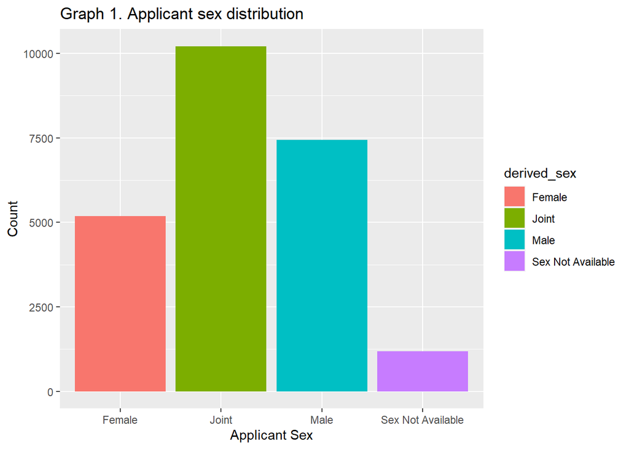

```r
library(ggplot2)
ggplot(loans, aes(x = factor(derived_sex), fill=derived_sex)) +
    geom_bar()+
  labs(title="Graph 1. Applicant sex distribution", x="Applicant Sex", y="Count")
```

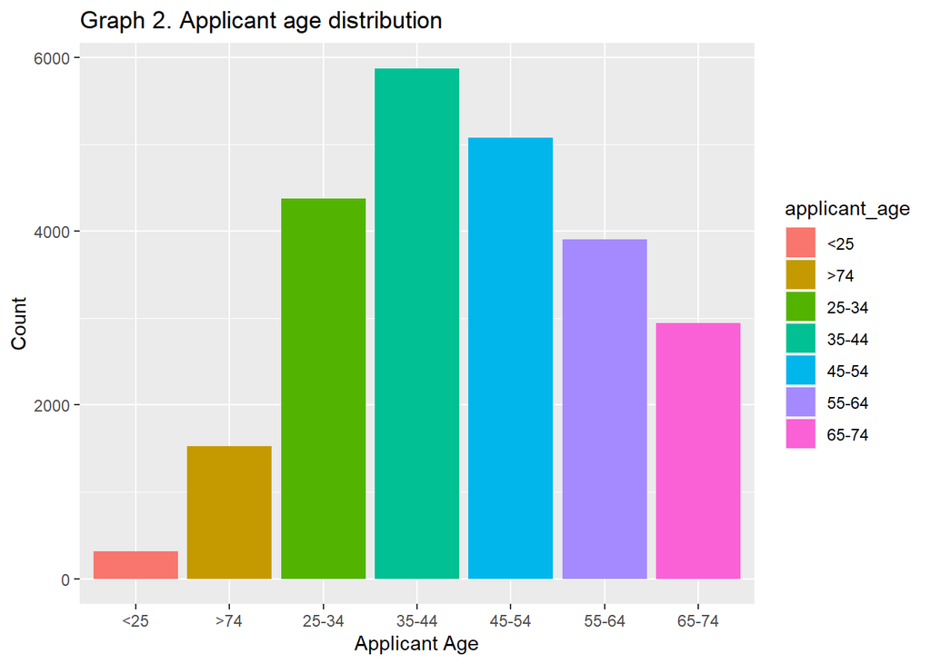

```r
ggplot(loans, aes(x = factor(applicant_age),fill=applicant_age)) +
    geom_bar()+
  labs(title="Graph 2. Applicant age distribution", x="Applicant Age", y="Count")
```

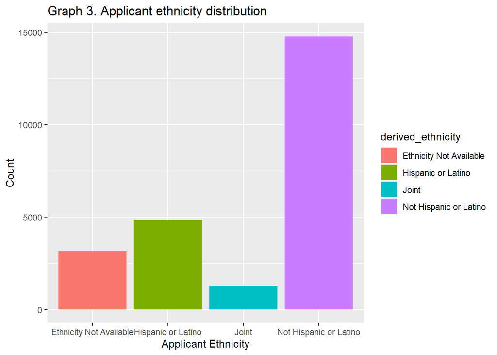

```r
ggplot(loans, aes(x = factor(derived_ethnicity), fill=derived_ethnicity)) +geom_bar()+
  labs(title="Graph 3. Applicant ethnicity distribution", x="Applicant Ethnicity", y="Count")
```

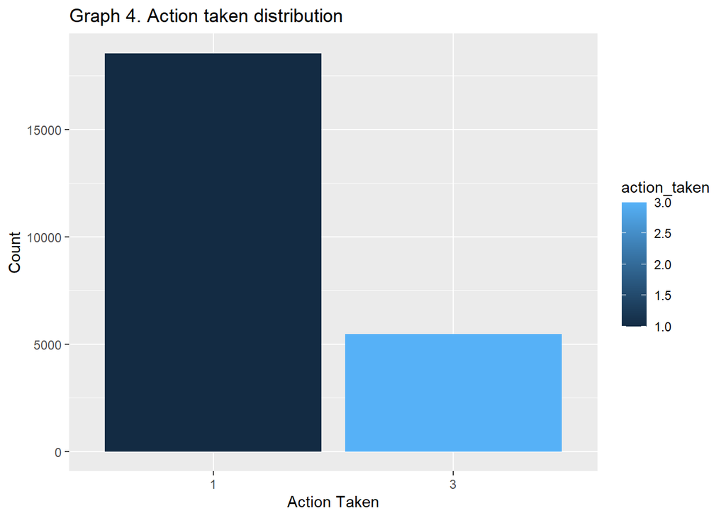

```r
ggplot(loans, aes(x = factor(action_taken), fill=action_taken)) +
    geom_bar()+
  labs(title="Graph 4. Action taken distribution", x="Action Taken", y="Count")
```

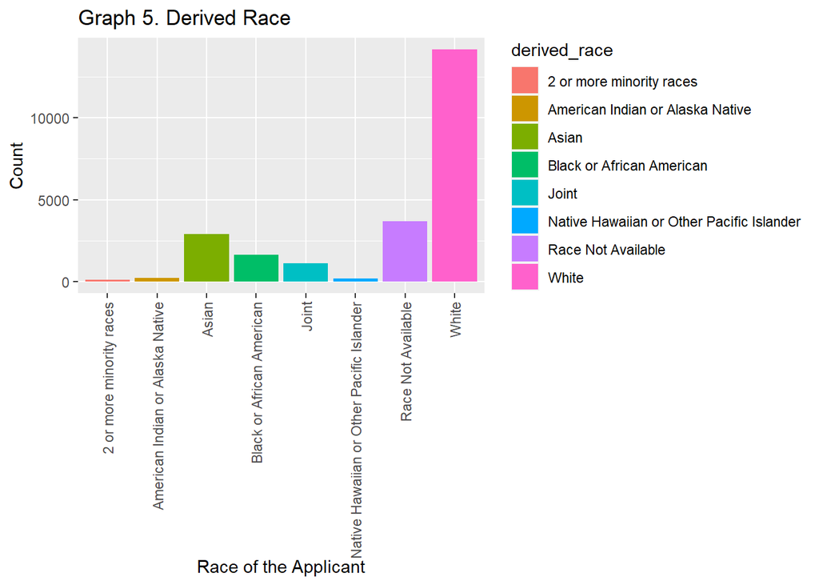

```r
ggplot(loans, aes(x = factor(derived_race), fill=derived_race)) +
    geom_bar()+
  labs(title="Graph 5. Derived Race", x="Race of the Applicant", y= "Count")+theme(axis.text.x = element_text(angle = 90, vjust = 0.5, hjust=1))
```

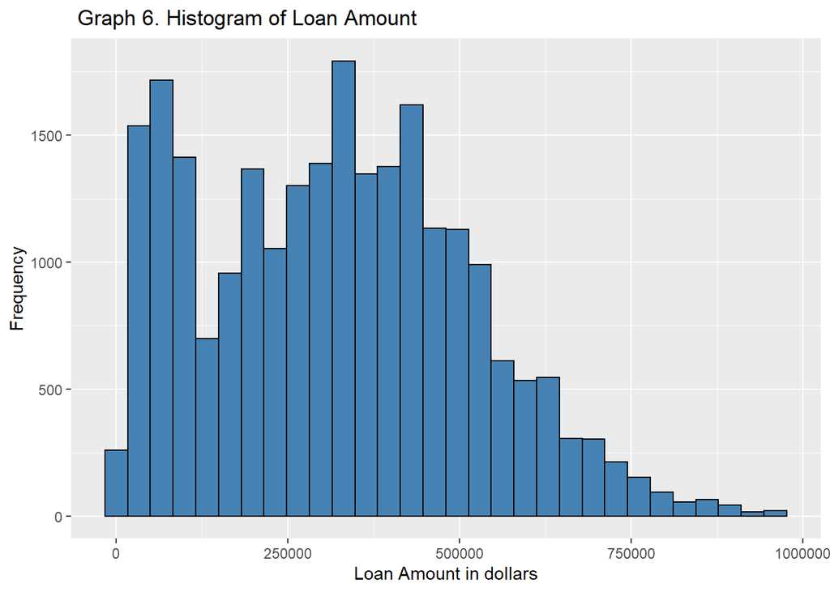

```r
ggplot(loans,aes(x=loan_amount))+
  geom_histogram(color="black", fill="steelblue")+
  labs(title=" Graph 6. Histogram of Loan Amount", x="Loan Amount in dollars", y="Frequency")
```

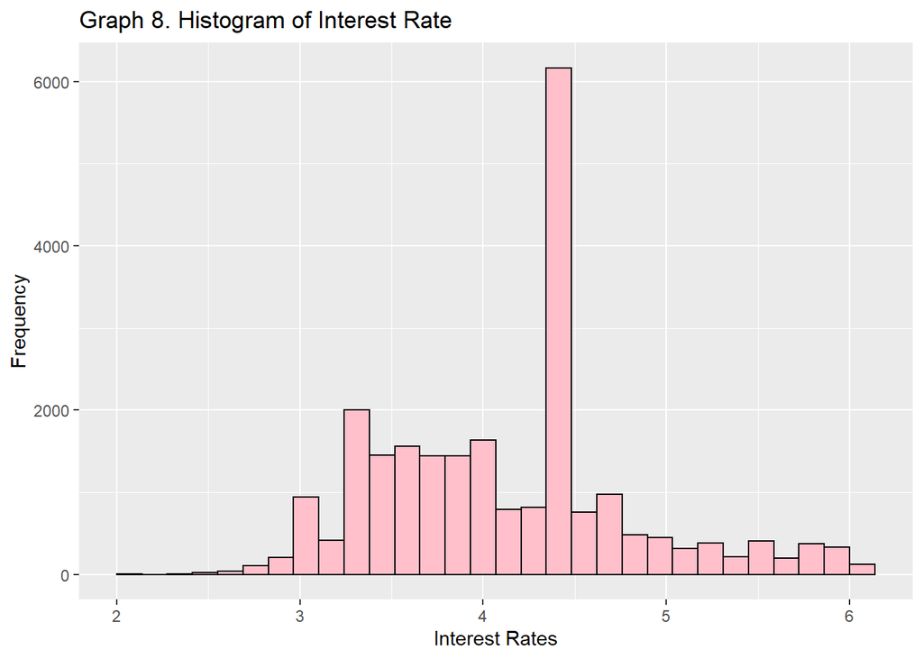

```r
ggplot(loans,aes(x=interest_rate))+
  geom_histogram(color="black", fill="pink")+
  labs(title="Graph 8. Histogram of Interest Rate", x="Interest Rates", y="Frequency")
```

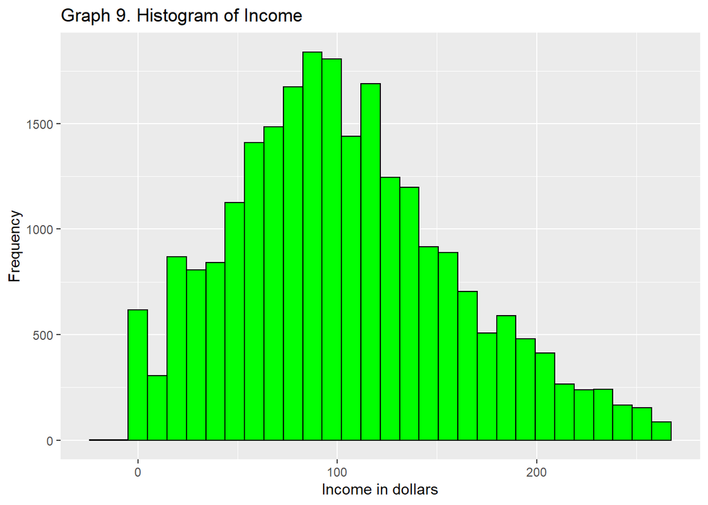

```r
ggplot(loans,aes(x=income))+
  geom_histogram(color="black", fill="green")+
  labs(title="Graph 9. Histogram of Income", x="Income in dollars", y="Frequency")
```

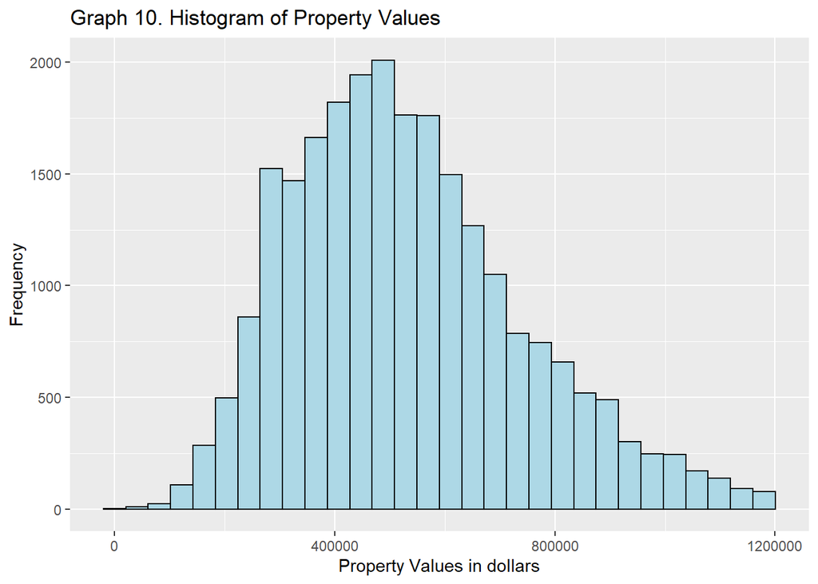

```r
ggplot(loans,aes(x=property_value))+
  geom_histogram(color="black", fill="lightblue")+
  labs(title="Graph 10. Histogram of Property Values", x="Property Values in dollars", y="Frequency")
```

#Balancing the dataset!

```r
hmda <- data.frame(loans)
hmda$approval<- ifelse(hmda$action_taken=="1", "Approved","Denied")
hmda$approval<- factor(hmda$approval)
str(hmda)
table(hmda$approval)
# Approved   Denied
#    18542     5476
```

Checking frequency of approval variable and derived_race variable

```r
with(hmda,
     {
       print(table(derived_race))
       print(table(approval))
     }
)
```

Creating DownSample of hmda dataset, the Approved far outnumber the Denied making this dataset severely unbalanced #Approved: 18542 Denied: 5476

```r
Approved<- which(hmda$action_taken=="1")
Denied<- which(hmda$action_taken=="3")
length(Approved)
length(Denied)
#The technique
approved_downsample<-sample(Approved,length(Denied))
hmda_down<- hmda[c(approved_downsample, Denied),]
str(hmda_down)
#10952 obs. of  11 variables
#Balanced Graph: confirming that it's balanced now
# ggplot(hmda_down, aes(x = factor(action_taken), fill=action_taken)) +
#     geom_bar()+
#   labs(title=" Action taken distribution in the Balanced Dataset", x="Action Taken", y="Count")
```

###The CHI SQUARE TESTS on balanced dataset Conducting Chi-squared Test on the downsampled dataset (hmda_down)

P-Value for contable1 is lower than .05 therefore we reject the null hypothesis. action_taken and derived_race are not independent of each other

```r
contable1= table(hmda_down$derived_race, hmda_down$action_taken)
xkabledply(contable1, title="Contingency table for Loan Approval and Race")
chitest1 = chisq.test(contable1)
chitest1
```

```r
contable2= table(hmda_down$derived_ethnicity, hmda_down$action_taken)
xkabledply(contable2, title="Contingency table for Loan Approval and Ethnicity")
chitest2 = chisq.test(contable2)
chitest2
```

```r
contable3= table(hmda_down$derived_sex, hmda_down$action_taken)
xkabledply(contable3, title="Contingency table for Loan Approval and Gender")
chitest3 = chisq.test(contable3)
chitest3
```

```r
contable4= table(hmda_down$applicant_age, hmda_down$action_taken)
xkabledply(contable4, title="Contingency table for Loan Approval and Age")
chitest4 = chisq.test(contable4)
chitest4
```

#Building the logit model” Changing action_taken to factor for logit/recode 1 as denial and 0 as approval because we want to calculate the probability of denial

```r
hmda_down$action_taken<-dplyr::recode(hmda_down$action_taken, "3"="1", "1"="0")
unique(hmda_down$action_taken)
hmda_down$action_taken<-factor(hmda_down$action_taken)
str(hmda_down)
myvars <- names(hmda_down) %in% c("approval") # dropping approval since we don't need this variable anymore
newdata <- hmda_down[!myvars]
hmda_down<-newdata
str(hmda_down)
```

### Logit models for action_taken (version with recoded approval/denial)

```r
###using all the variables of interest first
approval_logit <- glm(action_taken ~ derived_race + derived_ethnicity + derived_sex + loan_amount+applicant_age+ income+interest_rate+property_value, data = hmda_down, family = "binomial")
summary(approval_logit)
xkablevif(approval_logit) #check for multicollinearity
unique(hmda_down$action_taken)
```

```r
approvalNullLogit <- glm(action_taken ~ 1, data = hmda_down, family = "binomial")
mcFadden = 1 - logLik(approval_logit)/logLik(approvalNullLogit)
mcFadden
```

#### Hosmer and Lemeshow test

The Hosmer and Lemeshow Goodness of Fit test can be used to evaluate logistic regression fit.

```r
loadPkg("ResourceSelection") # function hoslem.test( ) for logit model evaluation
approveLogitHoslem = hoslem.test(hmda_down$action_taken, fitted(approval_logit)) # Hosmer and Lemeshow test, a chi-squared tests
unloadPkg("ResourceSelection")
approveLogitHoslem
```

Per Hosmer and Leshow, our model is quite poor; p-value is extremely low

```r
approveLogitHoslem
```

```
##
##  Hosmer and Lemeshow goodness of fit (GOF) test
##
## data:  hmda_down$action_taken, fitted(approval_logit)
## X-squared = 10952, df = 8, p-value <2e-16
```

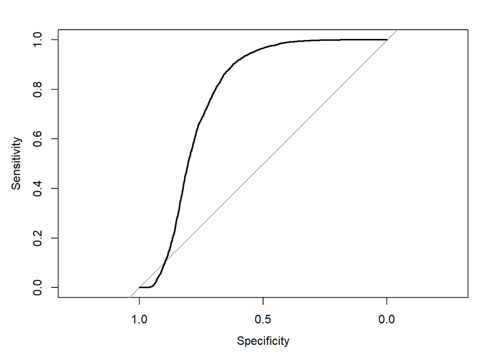

```r
loadPkg("pROC")
prob=predict(approval_logit, type = "response" )
hmda_down$prob=prob
h <- roc(action_taken~prob, data=hmda_down)
auc(h) # area-under-curve prefer 0.8 or higher.
plot(h)
```

```r
# unloadPkg("pROC")
```

###Feature Selection for Logit#####

```r
library(bestglm)
str(hmda_down)
fs_hmda_down<-hmda_down
fs_hmda_down$y = hmda_down[,4]
str(fs_hmda_down)
fs_hmda_down<-fs_hmda_down[c(1:3, 5:9, 11)] #subset for feature selection model that does not include action_taken
str(fs_hmda_down)
res.bestglm <- bestglm(Xy = fs_hmda_down, family = binomial,
            IC = "AIC",                 # Information criteria for
            method = "exhaustive")
summary(res.bestglm)
res.bestglm$BestModels
summary(res.bestglm$BestModels)
#https://rstudio-pubs-static.s3.amazonaws.com/2897_9220b21cfc0c43a396ff9abf122bb351.html
```

#Feature selection shows that the lowest AIC would use all variables, but not certain this is true; trying the second best without the derived sex

```r
approval_logit1 <- glm(action_taken ~ derived_race + derived_ethnicity + loan_amount+applicant_age+ income+interest_rate+property_value, data = hmda_down, family = "binomial")
summary(approval_logit1)
xkablevif(approval_logit) #check for multicollinearity
unique(hmda_down$action_taken)
```

#McFadden isn’t much improved

```r
approvalNullLogit <- glm(action_taken ~ 1, data = hmda_down, family = "binomial")
mcFadden = 1 - logLik(approval_logit1)/logLik(approvalNullLogit)
mcFadden
```

#Area under curve is slightly worse than in first:0.777

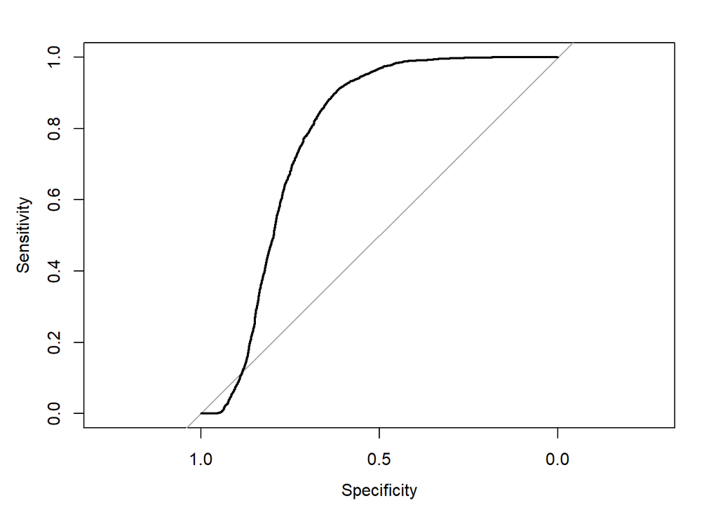

```r
loadPkg("pROC")
prob=predict(approval_logit1, type = "response" )
hmda_down$prob=prob
h <- roc(action_taken~prob, data=hmda_down)
auc(h) # area-under-curve prefer 0.8 or higher.
plot(h)
```

```r
# unloadPkg("pROC")
```

#Try standardizing the data?

```r
std_hmda_down<-hmda_down
std_hmda_down$loan_amount<-hmda_down$loan_amount/1000
std_hmda_down$property_value<-hmda_down$property_value/1000
approval_std <- glm(action_taken ~ derived_race + derived_ethnicity + loan_amount+applicant_age+ income+property_value, data = std_hmda_down, family = "binomial")
summary(approval_std)  #### took the interest rate out too
xkablevif(approval_std) #check for multicollinearity
```

#Sampling down: drawing a random sample

```r
set.seed(123)
index <- sample(nrow(hmda_down),nrow(hmda_down)*0.80)
training = hmda_down[index,]
testing = hmda_down[-index,]
hmda_glm0 <- glm(action_taken ~ derived_race + derived_ethnicity + derived_sex + loan_amount+applicant_age+ income+interest_rate+property_value, data = training, family = "binomial")
summary(hmda_glm0)
```

```r
summary(training)
summary(testing)
```

glm(formula = action_taken ~ derived_sex + loan_amount + income + property_value, family = “binomial”, data = training)

```r
hmda_glm_back <- step(hmda_glm0) #backward selections
summary(hmda_glm_back)
hmda_glm_back$deviance
AIC(hmda_glm_back)
```

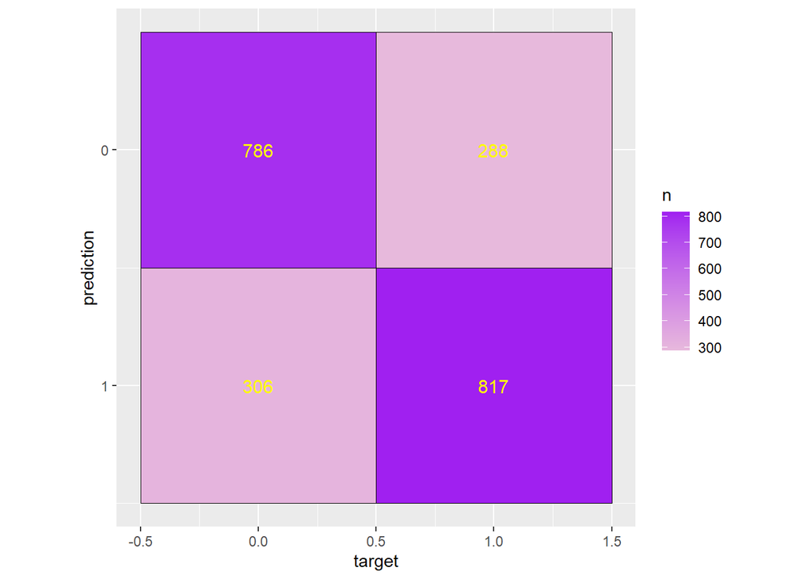

```r
library(caret)
glm_fit = glm(action_taken ~ derived_race + derived_ethnicity + loan_amount+applicant_age+ income+interest_rate+property_value, data = training, family = "binomial")

glm_probs = data.frame(probs = predict(glm_fit,
                                       newdata = testing,
                                       type="response"))

glm_pred = glm_probs %>%
  mutate(pred = ifelse(probs>.5, "1", "0"))



pc<-factor(glm_pred$pred)
e<- (testing$action_taken)


table(pc)
table(e)


confusionMatrix(data=pc, reference = e)


x<-data.frame("target"=c(1,0,1,0), "prediction"=c(1,1,0,0), "n"=c(817,306,288,786))

library(ggplot2)

ggplot(x, aes(x = target, y = prediction, fill = n)) +
  geom_tile(color = "black") +
  geom_text(aes(label = n), color = "Yellow", size = 4) +
  coord_fixed()+
  scale_fill_gradient2(low = "#075AFF",
                       mid = "#FFFFCC",
                       high = "Purple") +
     scale_y_continuous(trans = "reverse", breaks = unique(x$prediction))
```

# decision trees

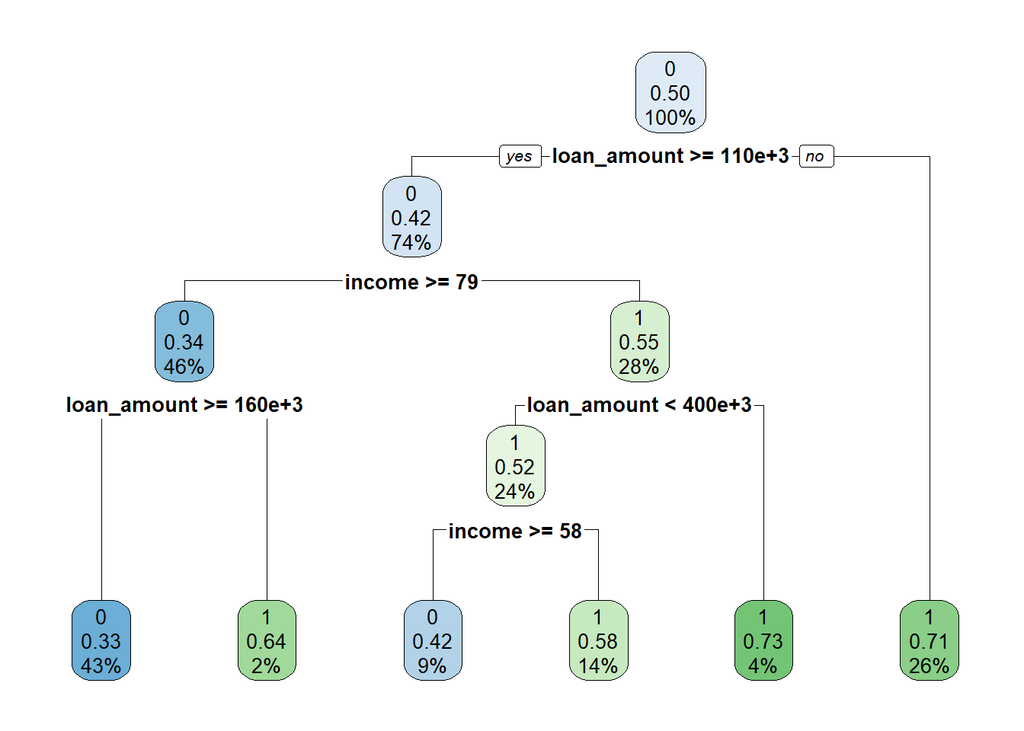

```r
library(rpart)
library(rpart.plot)
fit <- rpart(action_taken~derived_sex + loan_amount + income +
    property_value, data = training, method = 'class')
rpart.plot(fit, extra = 106)
```

#making a prediction

```r
predict_unseen <-predict(fit, testing, type = 'class')
```

#Create a table to count how many applicants are classified as approval and denied

```r
table_mat <- table(testing$action_taken, predict_unseen )
table_mat
```

#Measure performance:confustion martrix

```r
accuracy_Test <- sum(diag(table_mat)) / sum(table_mat)#0.655
```

We have a score of 66 percent for the test set.